# FOR/STT 875, DSP Exercise

Samantha Petrovich

## Learning objectives

- Download, manipulate, and play audio files using R
- Produce spectrograms of audio files
- Use acoustic indices in the `soundecology` package to analyze western New York soundscape data

## Overview

Update the `exercise_dsp.Rmd` file.

## Submission instructions

Upload your `exercise_dsp.Rmd` and `exercise_dsp_html` to the Digital Signal Processing Exercise D2L dropbox. Also, please, fill in the feedback questions at the end of the exercise.

## Grading

Exercise DSP consists of 7 possible points. For final grading, the exercise will be scaled to a grade out of 10 total points so that each exercise is worth the same amount. Although not graded, please fill in the feedback questions at the end of the exercise.

- 1 point for the R Markdown document compiling without error.
- 1 point for each TODO (6 total points). Partial credit will be awarded if the answer is not correct but displays some level of understanding of the underlying concept.

## Getting started

As always, set some global options to make the R code printed in the html output look nice.

```r
knitr::opts_chunk$set(comment = NA)
```

In this exercise we will use the packages `tuneR` and `seewave`, two packages designed for audio analysis in R that we saw in Chapter 14. We will also utilize the `soundecology` package to work with soundscape data. This package provides numerous functions to compute common indices in the growing field of environmental acoustics (or ecoacoustics). Install the `soundecology` package if you have not already done so.

## Temporal Variation of a Soundscape

We will explore the daily temporal variation of a soundscape in a small forest plot located in the Avon Driving Park in Avon, New York. This plot is bordered by a stream, soccer fields, and a farm/grassland, which draws in a lot of different species of birds due to the variety of habitats. Three 30 minute recordings were taken at 6:32 AM, 12:11 PM, and 7:37 PM. Let’s first get the recordings. For this exercise we are only going to work with 1 minute of these sound files. As we have done in previous exercises, we use the `downloader` package to download the soundscapes and unzip them into a directory. We then read the songs into R.

```r
library(tuneR)
library(downloader)

download("http://www.finley-lab.com/files/data/tempVarSongs.zip",
         destfile="./tempVarSongs.zip", mode="wb")

unzip("tempVarSongs.zip", exdir = ".")

list.files("tempVarSongs")
```

```
[1] "tempAfternoon.wav" "tempEvening.wav"   "tempMorning.wav"
```

```r
morning <- readWave("tempVarSongs/tempMorning.wav")
afternoon <- readWave("tempVarSongs/tempAfternoon.wav")
evening <- readWave("tempVarSongs/tempEvening.wav")
morning
```

```
Wave Object
    Number of Samples:      2646000
    Duration (seconds):     60
    Samplingrate (Hertz):   44100
    Channels (Mono/Stereo): Stereo
    PCM (integer format):   TRUE
    Bit (8/16/24/32/64):    16
```

```r
afternoon
```

```
Wave Object
    Number of Samples:      2646000
    Duration (seconds):     60
    Samplingrate (Hertz):   44100
    Channels (Mono/Stereo): Stereo
    PCM (integer format):   TRUE
    Bit (8/16/24/32/64):    16
```

```r
evening
```

```
Wave Object
    Number of Samples:      2646000
    Duration (seconds):     60
    Samplingrate (Hertz):   44100
    Channels (Mono/Stereo): Stereo
    PCM (integer format):   TRUE
    Bit (8/16/24/32/64):    16
```

Notice that the sound was recorded in stereo and has a sampling rate of 44.1 kHz (i.e the audio recorder took 44,100 samples per second). Now play the sound files using the `play` function described in the textbook (the exact arguments you give to this function may differ depending on your operating system). NOTE: you should actually listen to the audio when doing this exercise, but we don’t want the `play` function to run in the actual R Markdown file as R would play the audio before the file is compiled. This is why the option `eval = FALSE` is included in the below chunk.

```r
# TODO 17.1: write code to play the three sound files within R
library(tuneR)
play(morning)
play(afternoon)
play(evening)
```

Next, produce the spectrograms for each recording. The simplest way to do this requires the `seewave` package.

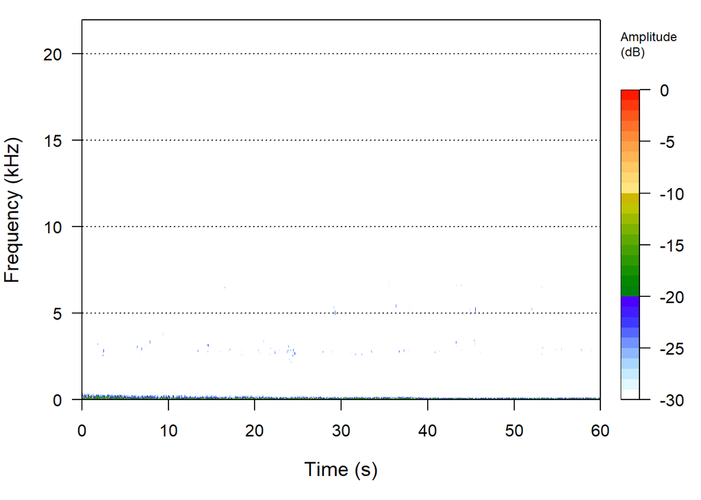

```r
# TODO 17.2 Produce the spectrograms for all three sounds
library(seewave)

spectro(morning)
```

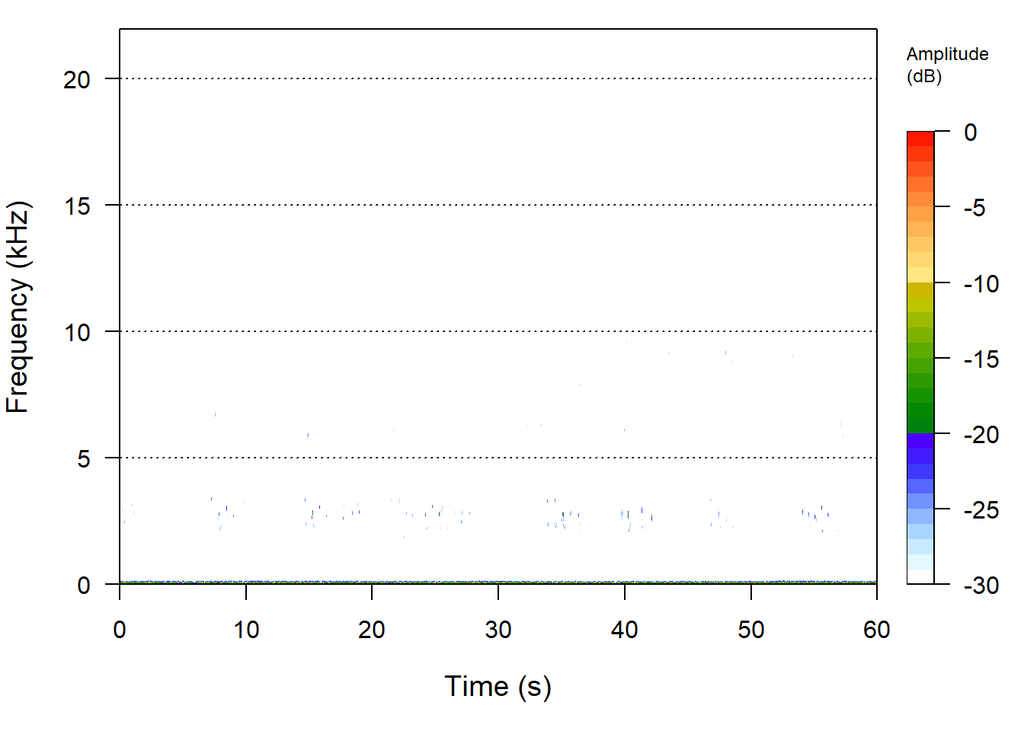

```r
spectro(afternoon)
```

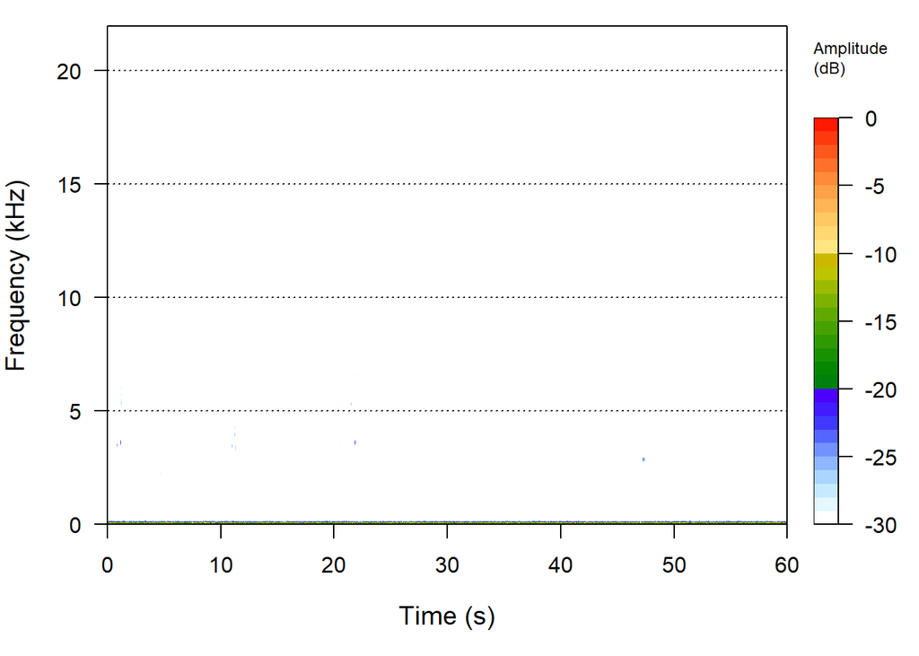

```r
spectro(evening)
```

If you do this correctly, you sholud barely see anything in your spectrograms. This is because there is noise in the recordings at low frequencies that is overpowering the biological sounds. Use the `help` function to explore the `spectro` function and determine a way to plot the spectrogram for the morning recording again but only for the frequency values of 2kHz-10kHz.

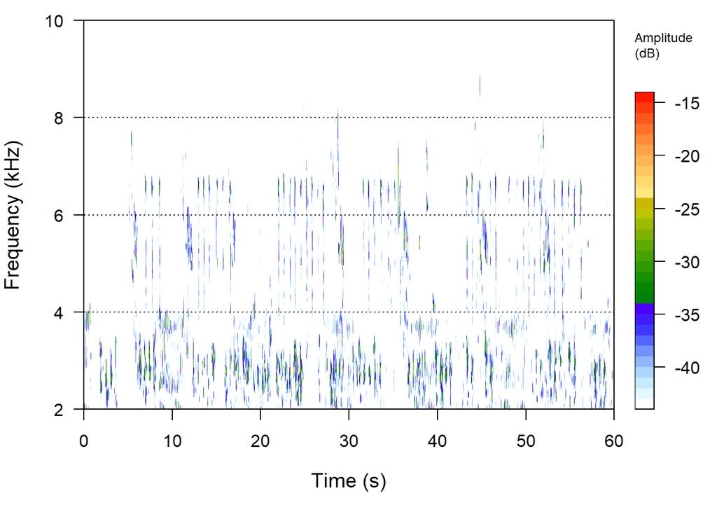

```r
# TODO 17.3: Reproduce the morning spectrogram over the frequency range 2kHz - 10kHz.

spectro(morning, flim = c(2,10))
```

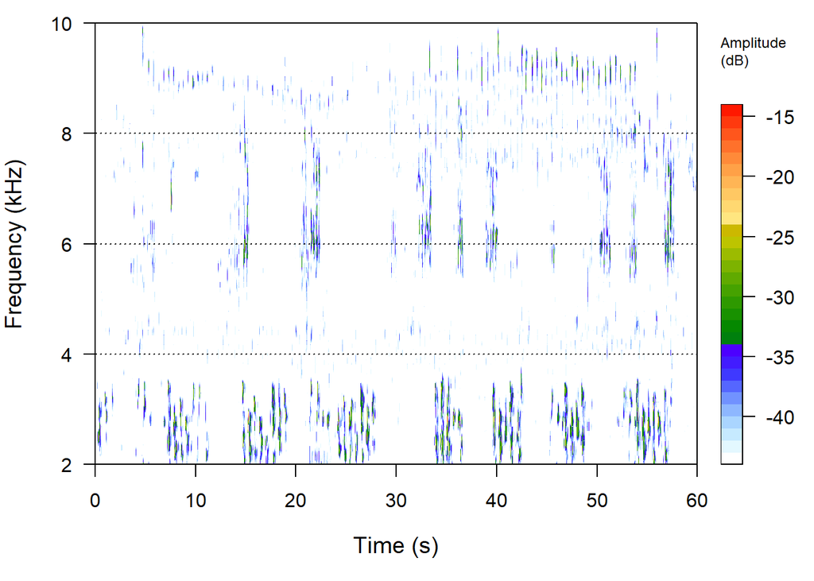

```r
spectro(afternoon, flim = c(2,10))
```

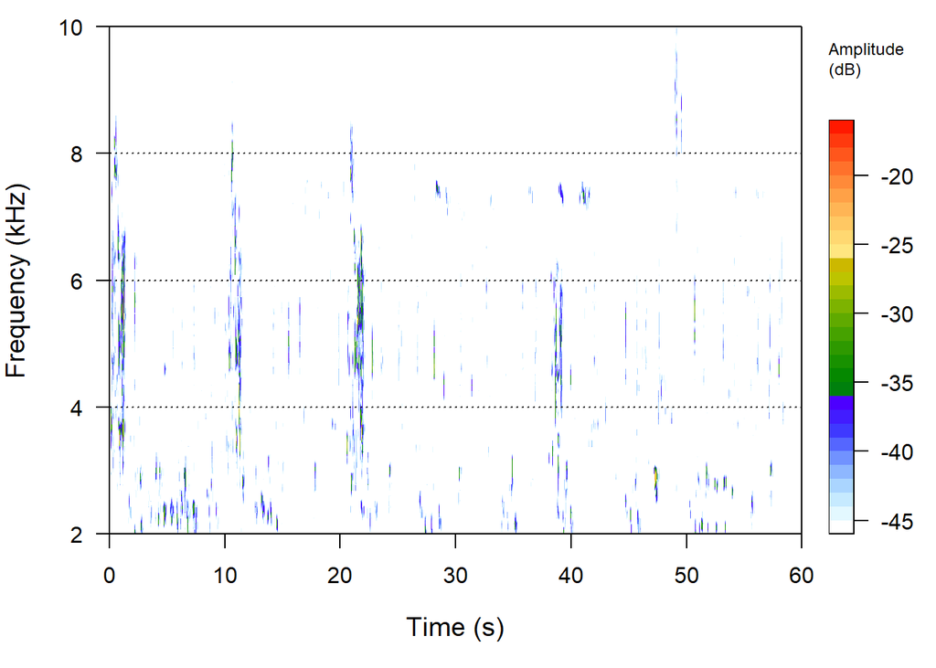

```r
spectro(evening, flim = c(2,10))
```

Now let’s read the csv file into R so we can work with the data. We convert `temporalData$FILENAME` into an ordered factor so that we can produce visualizations of the recordings in the desired form (morning then afternoon then evening).

```r
temporalData <- read.csv("data.csv", stringsAsFactors = FALSE)
head(temporalData)
```

```
           FILENAME SAMPLINGRATE BIT DURATION CHANNELS              INDEX
1 tempAfternoon.wav        44100  16       60        2 acoustic_diversity
2 tempAfternoon.wav        44100  16       60        2 acoustic_diversity
3   tempEvening.wav        44100  16       60        2 acoustic_diversity
4   tempEvening.wav        44100  16       60        2 acoustic_diversity
5   tempMorning.wav        44100  16       60        2 acoustic_diversity
6   tempMorning.wav        44100  16       60        2 acoustic_diversity
  MAX_FREQ DB_THRESHOLD FREQ_STEPS LEFT_CHANNEL RIGHT_CHANNEL
1    16000            -       1000     2.277086      2.290148
2    16000           50       1000     2.277086      2.290148
3    16000            -       1000     1.524893      1.536908
4    16000           50       1000     1.524893      1.536908
5    16000            -       1000     1.954692      1.972714
6    16000           50       1000     1.954692      1.972714
```

```r
temporalData$FILENAME <- factor(temporalData$FILENAME, levels = c("tempMorning.wav", "tempAfternoon.wav",
                                                                  "tempEvening.wav"), ordered = TRUE)
```

Notice that each entry has two rows that are identical (this is a result of the sound files being stereo recordings). Change the `temporalData` data frame to include only the odd rows.

```r
# TODO 17.4: remove the even rows from temporalData

temporalData[-c(2,4,6),]
```

```
           FILENAME SAMPLINGRATE BIT DURATION CHANNELS              INDEX
1 tempAfternoon.wav        44100  16       60        2 acoustic_diversity
3   tempEvening.wav        44100  16       60        2 acoustic_diversity
5   tempMorning.wav        44100  16       60        2 acoustic_diversity
  MAX_FREQ DB_THRESHOLD FREQ_STEPS LEFT_CHANNEL RIGHT_CHANNEL
1    16000            -       1000     2.277086      2.290148
3    16000            -       1000     1.524893      1.536908
5    16000            -       1000     1.954692      1.972714
```

There appears to be some slight differences in the ADI across the sound files. Produce a bar graph using `ggplot2` that shows the variation of the ADI across the three time periods. Only worry about the `LEFT_CHANNEL` values and not the `RIGHT_CHANNEL` values. Make sure your plot looks exactly like the following:

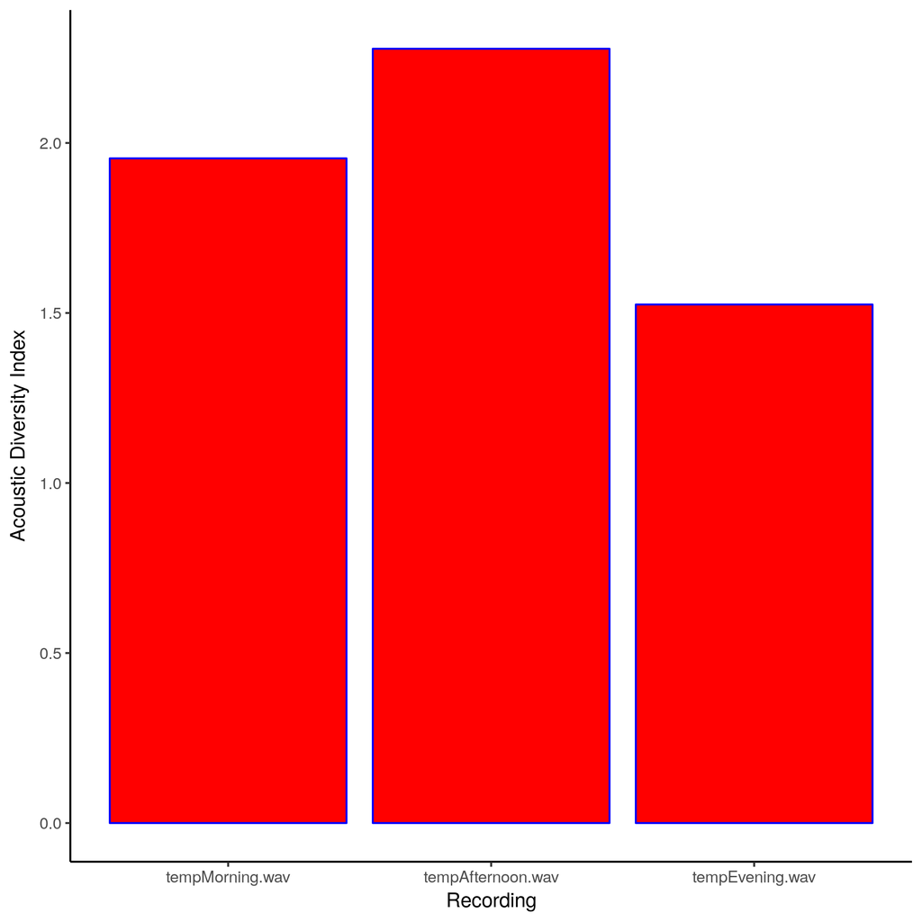

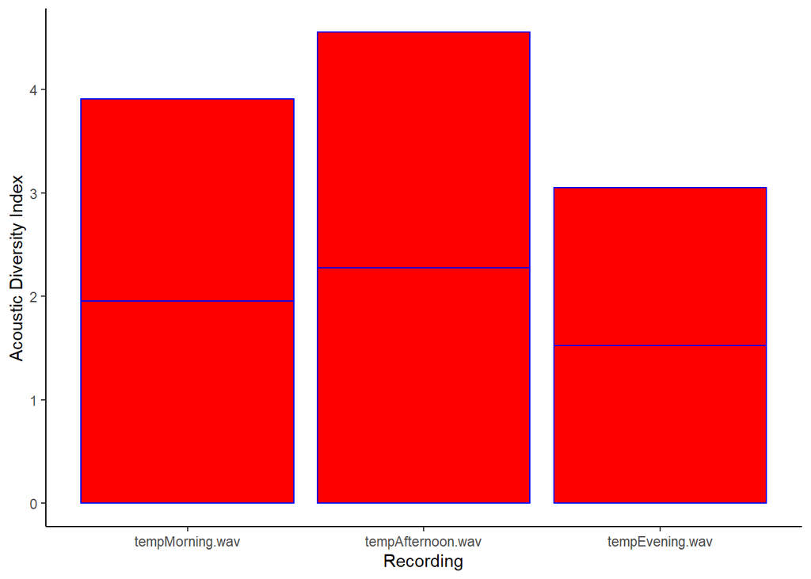

```r
# TODO 17.5: produce a bar plot of the left channel ADI values across the three time periods
library(ggplot2)
ggplot(data = temporalData, aes(x = FILENAME, y = LEFT_CHANNEL)) +
  geom_bar(stat = "identity", color = "blue", fill = "red") +
  labs(y = "Acoustic Diversity Index", x = "Recording") +
  theme_classic()
```

Cool, we see some differences between the morning, afternoon, and evening (you would have to get more data and perform statistical tests to see if there is actually a significant difference in these time periods, but that is beyond the scope of this exercise). What we can do is look further into the ADI. Use `?acoustic_diversity` to look up the ADI function and look through the value section. Specifically check out the `left_band_values` object. This object is a “vector of proportion values for each band for the left channel”. In other words, this function will give us the amplitude value for each frequency bin, allowing us to understand which frequency band of sound is dominating the soundscape. Let’s compare this across the three recordings to see if different frequency bands are dominating the recordings (which would thus tell us the composition of the soundscape changes across the three temporal periods). Compute the ADI manually for the three recordings, explore the structure of the data, perform any necessary manipulations, and then plot the data using `ggplot2`. This is a substantial challenge, so be ready to spend some time manipulating the data. The goal is to produce the graph pictured below.

Here are some potentially useful (or maybe not useful) hints:

1. Compute the Acoustic Diversity for each song
2. Produce a new data frame that has three variables: `values`, `range`, and `time`. For example, the first row in this data frame could have values `0.781950, 1, morning`, respectively.
3. Plot using `ggplot` and `geom_bar`.

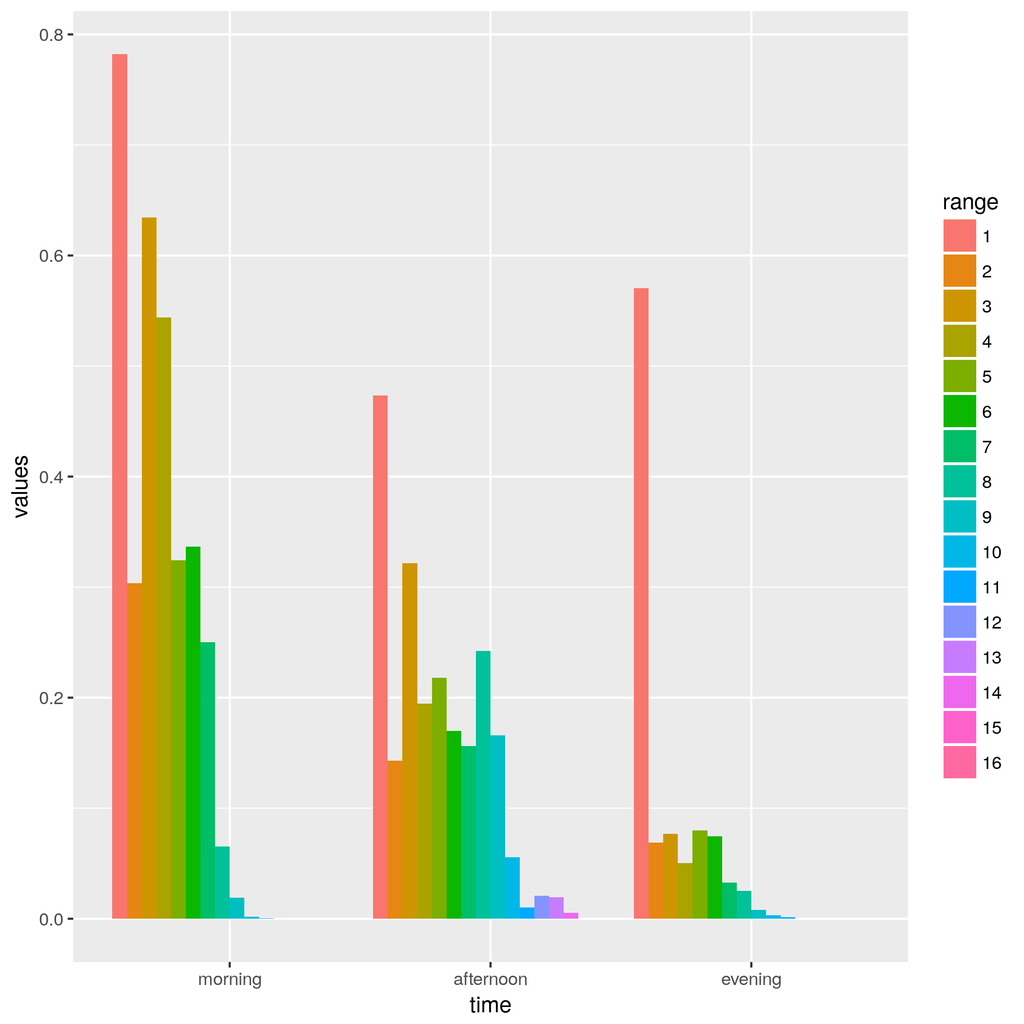

```r
# TODO 17.6: Produce the figure above

adiMorning <- acoustic_diversity(morning, max_freq = 16000)
```

```
 This is a stereo file. Results will be given for each channel.

 Calculating index. Please wait...

  Acoustic Diversity Index:
   Left channel: 1.954692
   Right channel: 1.972714
```

```r
adiAfternoon <- acoustic_diversity(afternoon, max_freq = 16000)
```

```
 This is a stereo file. Results will be given for each channel.

 Calculating index. Please wait...

  Acoustic Diversity Index:
   Left channel: 2.277086
   Right channel: 2.290148
```

```r
adiEvening <- acoustic_diversity(evening, max_freq =  16000)
```

```
 This is a stereo file. Results will be given for each channel.

 Calculating index. Please wait...

  Acoustic Diversity Index:
   Left channel: 1.524893
   Right channel: 1.536908
```

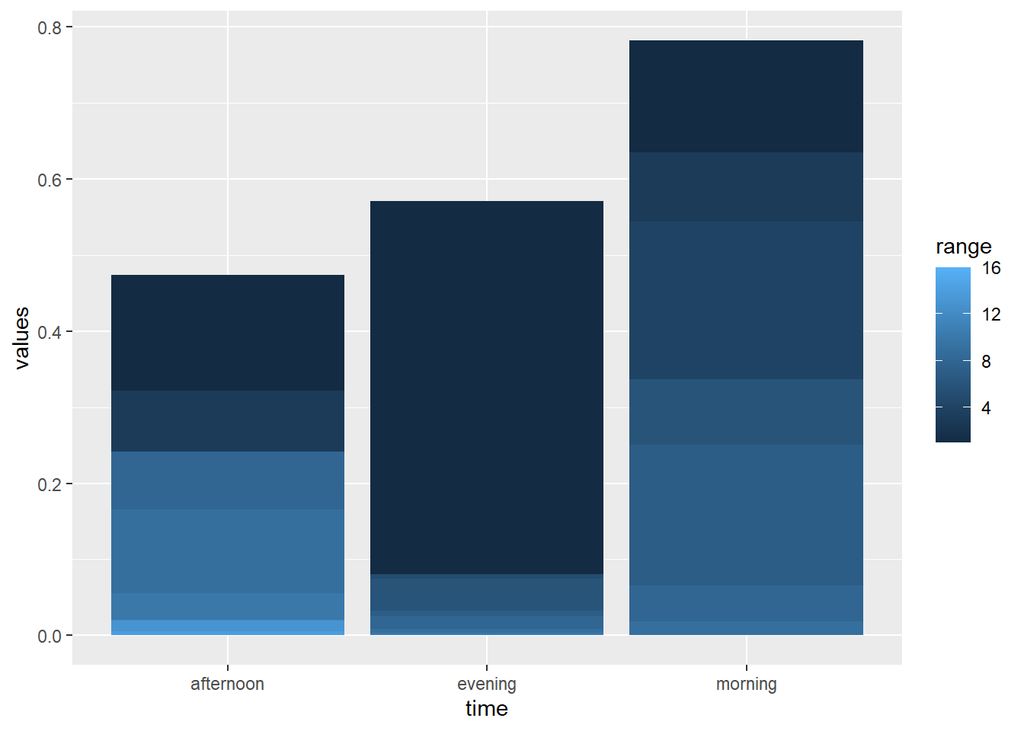

```r
longADIMorning <- data.frame(adiMorning$left_band_values, 1:length(adiMorning$left_band_values),
                             rep("morning", times = length(adiMorning$left_band_values)))
colnames(longADIMorning) <- c("values", "range", "time")

longADIAfternoon <- data.frame(adiAfternoon$left_band_values, 1:length(adiAfternoon$left_band_values),
                             rep("afternoon", times = length(adiAfternoon$left_band_values)))
colnames(longADIAfternoon) <- c("values", "range", "time")

longADIEvening <- data.frame(adiEvening$left_band_values, 1:length(adiEvening$left_band_values),
                             rep("evening", times = length(adiEvening$left_band_values)))
colnames(longADIEvening) <- c("values", "range", "time")

ALL_ADI <- rbind(longADIMorning,longADIAfternoon,longADIEvening, deparse.level = 3)

ggplot(data = ALL_ADI, aes(x= time,y=values ,fill = range)) +
  geom_bar(position = "dodge", stat = "identity")
```

******

Congratulations! You’ve reached the end of Exercise 17.

### Questions?

If you have any lingering questions about the material in this document or in the corresponding chapter, put them here.

*I do have a question about the best way to go about 17.6, but I am planning on looking at the solution when that comes out. I did want to say how cool this Homework was! I have not been able to work with any audio in my coding experience before, so I was very excited about this.*

### Give us your feedback!

1. How do you feel you’re doing in this class?

*I feel that I am doing rather well in the class and I an thoroughly enjoying the class!*

2. What could be done to improve your learning experience?

*the class is set up well, so there aren’t any inprovements that I can think of.*